# TA Midterm Project Gahbiche

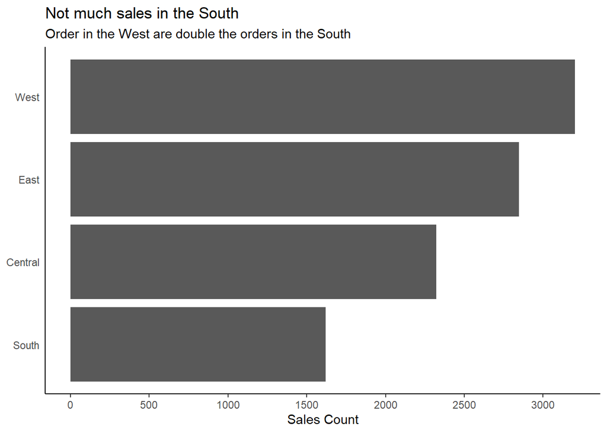

```r
OM %>%
  group_by(Region) %>%
  summarise(Count=n()) %>%

  ggplot(mapping = aes(reorder(x = Region,Count), y = Count)) +
  geom_bar(stat = "identity") +
  coord_flip() +
  theme_classic() +
  theme(axis.title.y = element_blank(),
    axis.ticks.y = element_blank()) +
  scale_y_continuous(breaks = seq(0,3000,500)) +
  labs ( title = "Not much sales in the South",
     subtitle = "Order in the West are double the orders in the South",
     x = "Region",
     y = "Sales Count")
```

**City**

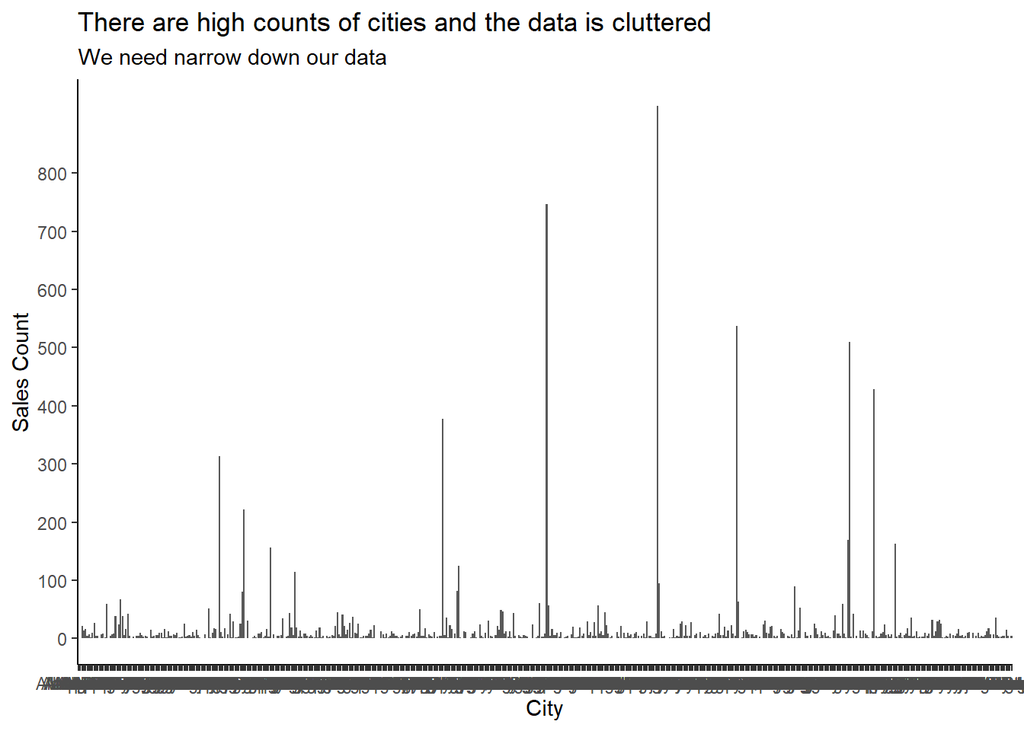

```r
OM %>%
  ggplot(mapping = aes(x = City)) +
  geom_bar() +
  theme_classic() +
  scale_y_continuous(breaks = seq(0,800,100)) +
  labs ( title = "There are high counts of cities and the data is cluttered",
         subtitle = "We need narrow down our data",
         x = "City",
         y = "Sales Count")
```

**Top Cities**

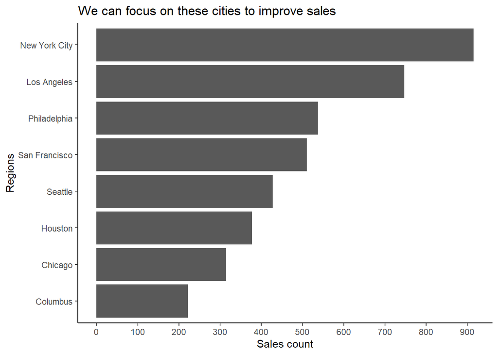

```r
# Narrowing down the city variable:

TopCities <- OM %>%
 group_by(City) %>%
 summarise(Count=n()) %>%
  filter(Count > 200)

TopCities %>%
  ggplot(mapping = aes(x= reorder(TopCities$City,Count), y = Count)) +
  geom_bar(stat = "identity")+
  coord_flip() +
  theme_classic() +
  scale_y_continuous(breaks = seq(0,1000,100)) +
  labs (title = "We can focus on these cities to improve sales",
         x = "Regions",
         y = "Sales count")
```

**States**

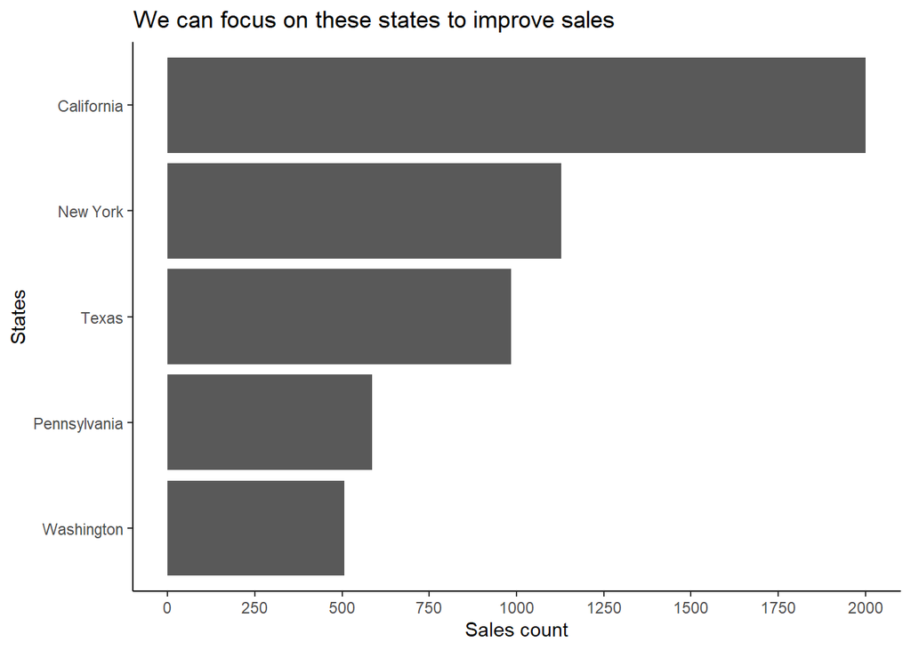

```r
# Narrowing down the State variable:

TopStates <- OM %>%
 group_by(State) %>%
 summarise(Count=n()) %>%
  filter(Count > 500)

TopStates %>%
  ggplot(mapping = aes(reorder(x= TopStates$State, TopStates$Count), y = TopStates$Count)) +
  geom_bar(stat = "identity")+
  coord_flip() +
  theme_classic() +
  scale_y_continuous(breaks = seq(0,2010,250)) +
  labs (title = "We can focus on these states to improve sales",
         x = "States",
         y = "Sales count")
```

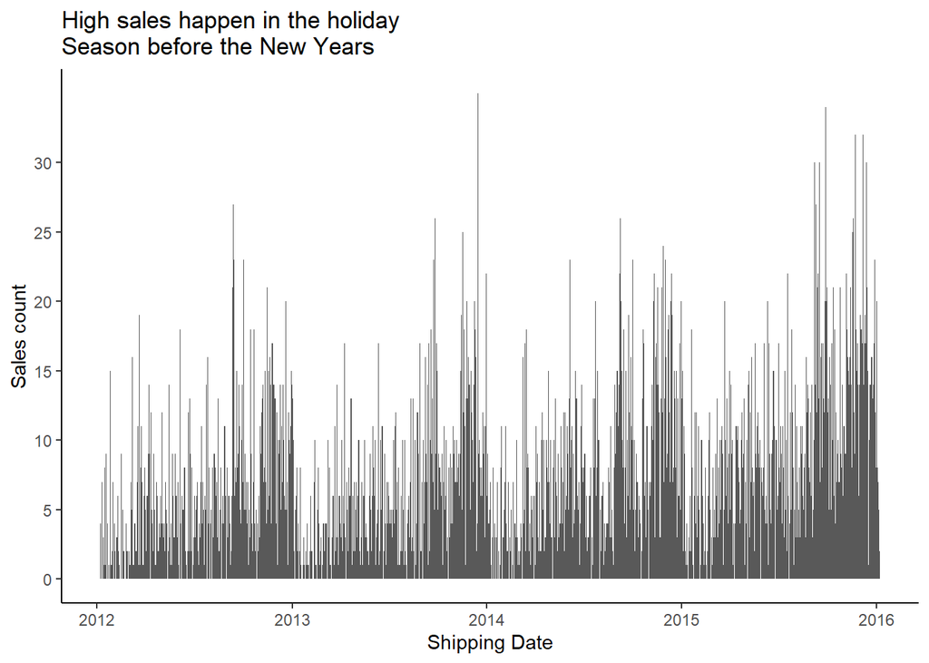

```r
OM %>%
  ggplot(mapping = aes(x = Ship.Date)) +
  geom_bar()+
  theme_classic() +
  scale_y_continuous(breaks = seq(0,30,5)) +
  labs (title = "High sales happen in the holiday\nSeason before the New Years",
         x = "Shipping Date",
         y = "Sales count")
```

**Comments**

- Shipping Mode:
- We might focus on Standard shipping as it is the most used shipping method.
- Customer Segment:
- Consumers brings the most sales. We will focus on this segment.
- Product Category:
- Office Supplies brings the most sales. We will focus on this segment.
- Product ID:
- There are 3 Products that bring most sales. We’ll advertise more of those products.
- Region:
- Most sales come from the West so we will focus on that geographical location.
- City:
- There were so many cities with small counts.
- We narrowed down our data to the top cities:
  - New York City, Los Angeles, Philadelphia, San Francisco, Seattle, Houston, Chicago, Columbus
- States:
- There were so many states with small counts.
- We narrowed down our data to the top states:
  - California, New York, Texas, Pennsylvania, Washington
- Shipping time:
- We have spikes in shipping at the end of each year, indicating that most people order for the holiday season.
- We can take adventage of that and sell more.
- We might want to look at each year separately using facets.

**Questions**

- What shipping method is generating the most profit?
- What shipping method has high costs?
- What is the relationship between product category and profit?
- What Region, City, State, brings the most profit?
- What is the time of the year where Office Mate has the highest sales every year?

## 6.2 Step 2.2: Quantitative

**Revenue**

```r
# Subsetting Revenue

Year1 <- subset(OM, format(as.Date(Ship.Date),"%Y")==2012)
Year2 <- subset(OM, format(as.Date(Ship.Date),"%Y")==2013)
Year3 <- subset(OM, format(as.Date(Ship.Date),"%Y")==2014)
Year4 <- subset(OM, format(as.Date(Ship.Date),"%Y")==2015)
```

**Revenue graphs of 2012 and 2013**

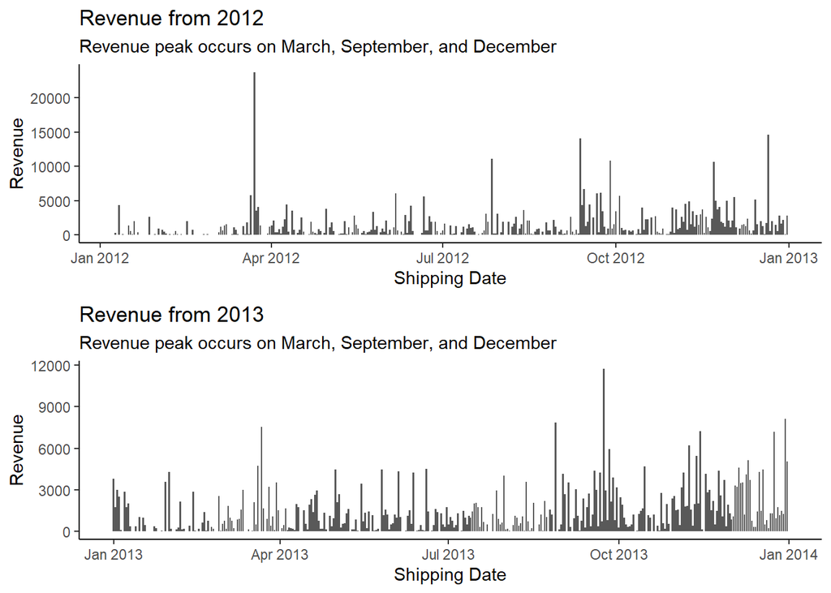

```r
grid.arrange(
Year1 %>%
  ggplot(mapping = aes(x = Ship.Date, y = Revenue)) +
  geom_bar(stat = "identity") +
  theme_classic() +
  labs(title = "Revenue from 2012",
       subtitle = "Revenue peak occurs on March, September, and December",
       x = "Shipping Date",
       y= "Revenue"),

Year2 %>%
  ggplot(mapping = aes(x = Ship.Date, y = Revenue)) +
  geom_bar(stat = "identity") +
  theme_classic() +
  labs(title = "Revenue from 2013",
       subtitle = "Revenue peak occurs on March, September, and December",
       x = "Shipping Date",
       y= "Revenue"),
ncol = 1
)
```

**Revenue graph 2014 and 2015**

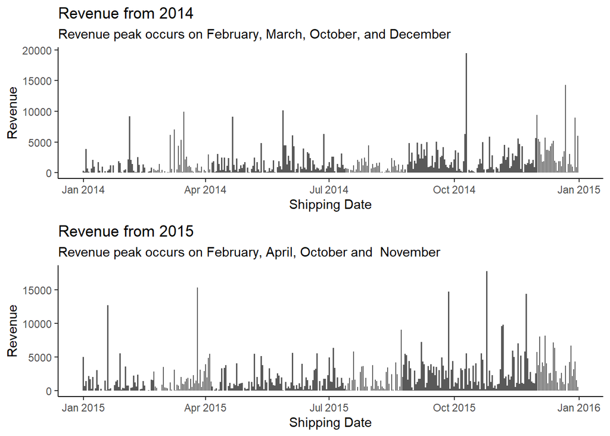

```r
grid.arrange(
Year3 %>%
  ggplot(mapping = aes(x = Ship.Date, y = Revenue)) +
  geom_bar(stat = "identity") +
  theme_classic() +
  labs(title = "Revenue from 2014",
       subtitle = "Revenue peak occurs on February, March, October, and December",
       x = "Shipping Date",
       y= "Revenue"),

Year4 %>%
  ggplot(mapping = aes(x = Ship.Date, y = Revenue)) +
  geom_bar(stat = "identity") +
  theme_classic() +
  labs(title = "Revenue from 2015",
       subtitle = "Revenue peak occurs on February, April, October and  November",
       x = "Shipping Date",
       y= "Revenue"),
ncol = 1
)
```

**Comments**

**Quantity per order**

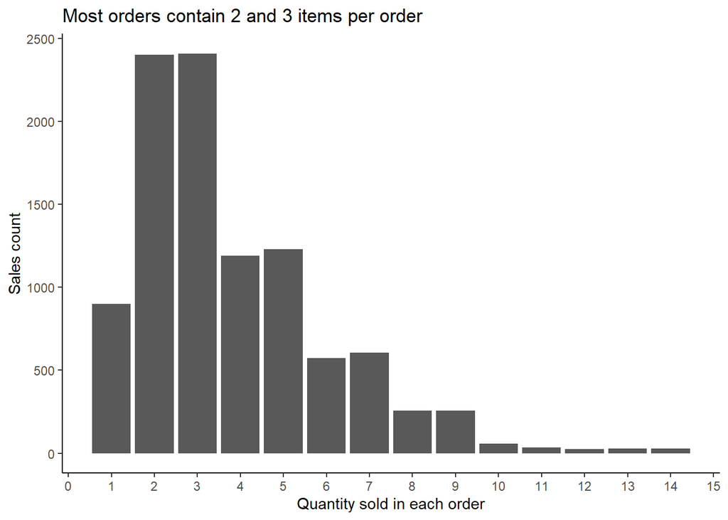

```r
graph1 <- OM %>%
  ggplot(mapping = aes(x = Quantity))+
  geom_bar(position = "dodge") +
  labs(title = "Most orders contain 2 and 3 items per order",
       x = "Quantity sold in each order",
       y = "Sales count") +
  theme_classic() +
  scale_x_continuous(breaks = seq(0,15,1))
graph1
```

**Comments**

- We can come up with a strategy for saving money if we somehow can make customers add more items per order.
- This will save us in the shipping and reduce waste.
- Ideally we want each order to contain 4 items or more.

**Discount**

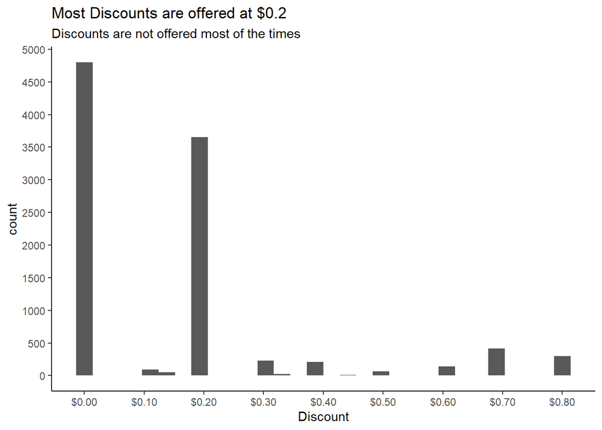

```r
OM %>%
  ggplot(mapping = aes(x = Discount)) +
  geom_histogram() +
  scale_x_continuous(breaks = seq(0,0.8,0.1), label = dollar)+
  scale_y_continuous(breaks = seq(0,5000,500)) +
  theme_classic() +
  labs(title = "Most Discounts are offered at $0.2",
       subtitle = "Discounts are not offered most of the times")
```

**Comments**

- There are many values below 500 and we would like to know how they compare to each other.
- So we will take a look at them by removing $0.00 and $0.20 from the graph.

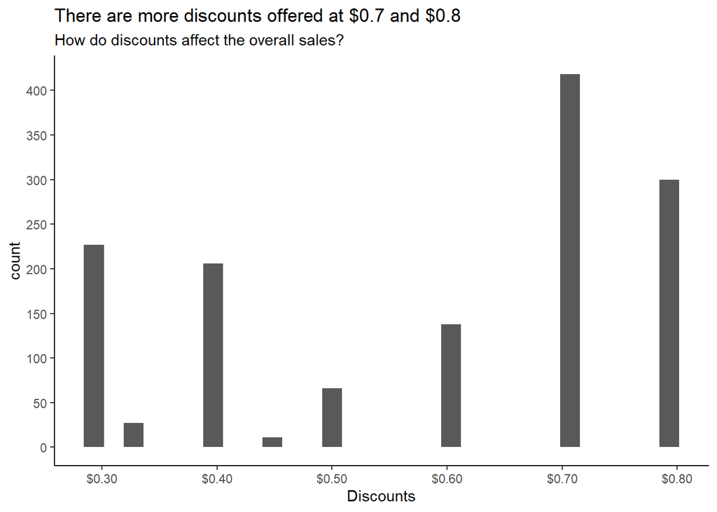

```r
OM %>%
  filter(Discount > 0.2) %>%
  ggplot(mapping = aes(x = Discount)) +
  geom_histogram() +
  scale_x_continuous(breaks = seq(0.2,0.8,0.1), label = dollar)+
  scale_y_continuous(breaks = seq(0,400,50)) +
  theme_classic() +
  labs(title = "There are more discounts offered at $0.7 and $0.8",
       subtitle = "How do discounts affect the overall sales?",
       x = "Discounts")
```

**Comments**

- A significant number of discounts are offered at $0.2.
- Office Mate doesn’t always offer discounts.
- Although there are disocunts for $0.7 and $0.8, those two combined don’t even represent 10% of the total dataset. Therefore, they are not very representative.

**Questions**

- Are discounts impacting sales?
- When should Office Mate offer high discounts?

**Cost and Revenue**

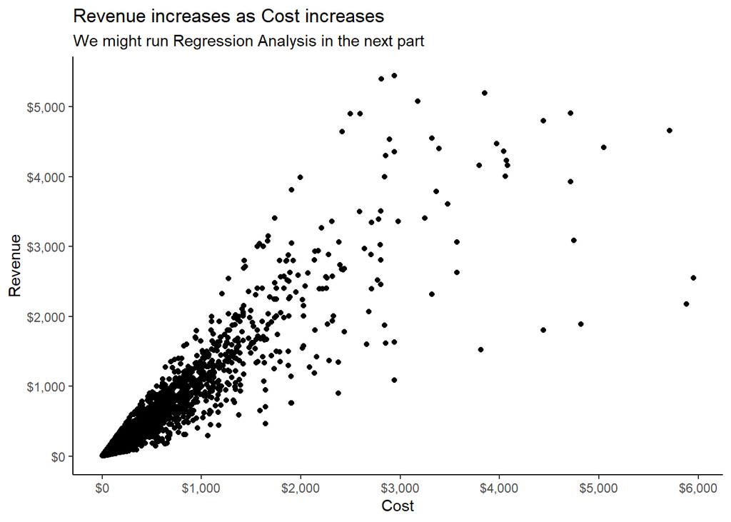

```r
OM %>%
  filter(Revenue < 6000 & Cost < 6000) %>%
  ggplot(mapping = aes(x = Cost, y = Revenue )) +
  geom_point() +
  theme_classic() +
  scale_x_continuous(breaks = seq(0,6000,1000), label = dollar) +
  scale_y_continuous(breaks = seq(0,6000,1000), label = dollar) +
  labs(title = "Revenue increases as Cost increases",
       subtitle = "We might run Regression Analysis in the next part")
```

# 7 Base EDA Step 3: Multi-variate non-graphical

## 7.1 Step 3.1: Categorical

```r
# Setting up tables setting

customGreen0 = "#DeF7E9"

customGreen = "#71CA97"

customRed = "#ff7f7f"

customRed0 = "#ffcccc"
```

**Segment and Category count**

```r
table1 <- OM %>%
  tabyl(Segment, Category) %>%
  adorn_totals(where = c("row","col"))

formattable(table1, align =c("l","c", "c", "c", "r"), list(
  `Segment` = formatter("span", style = ~ style(color = "grey",font.weight = "bold")),
  `Furniture`= color_tile(customGreen, customGreen0),
  `Office Supplies`= color_tile(customGreen, customGreen0),
  `Technology`= color_tile(customGreen, customGreen0),
  `Total` = color_tile(customRed,customRed0)
))
```

| Segment | Furniture | Office Supplies | Technology | Total |
| --- | --- | --- | --- | --- |
| Consumer | 1113 | 3127 | 951 | 5191 |
| Corporate | 646 | 1820 | 554 | 3020 |
| Home Office | 362 | 1079 | 342 | 1783 |
| Total | 2121 | 6026 | 1847 | 9994 |

**Segment and Category proportions**

```r
table2 <- OM %>%
  tabyl(Segment, Category) %>%
  adorn_totals(where = c("row", "col")) %>%
  adorn_percentages(denominator = "all") %>%
  adorn_rounding(2)

formattable(table2, align =c("l","c", "c", "c", "r"), list(
  `Segment` = formatter("span", style = ~ style(color = "grey",font.weight = "bold")),
  `Furniture`= color_tile(customGreen, customGreen0),
  `Office Supplies`= color_tile(customGreen, customGreen0),
  `Technology`= color_tile(customGreen, customGreen0),
  `Total` = color_tile(customRed,customRed0)
))
```

| Segment | Furniture | Office Supplies | Technology | Total |
| --- | --- | --- | --- | --- |
| Consumer | 0.11 | 0.31 | 0.10 | 0.52 |
| Corporate | 0.06 | 0.18 | 0.06 | 0.30 |
| Home Office | 0.04 | 0.11 | 0.03 | 0.18 |
| Total | 0.21 | 0.60 | 0.18 | 1.00 |

**Comments**

- **Consumer segment** is the one that sells the most in each product Category with **52%**
- **Office Supply** makes up **60%** of all product categories

**Questions**

- From which Region, State, and Region are the Office Supplies being ordered from?
- Where are most consumers ordering from?

```r
table3 <- OM %>%
  tabyl(Ship.Mode,Segment) %>%
  adorn_totals(where = c("row", "col")) %>%
  adorn_percentages(denominator = "all") %>%
  adorn_rounding(2)

formattable(table3, align =c("l","c", "c", "c", "r"), list(
  `Ship.Mode` = formatter("span", style = ~ style(color = "grey",font.weight = "bold")),
  `Consumer`= color_tile(customGreen, customGreen0),
  `Corporate`= color_tile(customGreen, customGreen0),
  `Home Office`= color_tile(customGreen, customGreen0),
  `Total` = color_tile(customRed,customRed0)
))
```

| Ship.Mode | Consumer | Corporate | Home Office | Total |
| --- | --- | --- | --- | --- |
| First Class | 0.08 | 0.05 | 0.03 | 0.15 |
| Same Day | 0.03 | 0.01 | 0.01 | 0.05 |
| Second Class | 0.10 | 0.06 | 0.03 | 0.19 |
| Standard Class | 0.31 | 0.18 | 0.11 | 0.60 |
| Total | 0.52 | 0.30 | 0.18 | 1.00 |

**Comments**

- It is clear that Consumers take up a large percentage of the orders using Stadard Class shipping with **31%** compared to **18%** for Corporate and **11%** for Home Office.
- A lot of consumers also use second class **10%**.

**Questions**

- How which Regions use the most standard shipping?
- How does the other proportion of shipping methods look like for all Regions?

```r
table4 <- OM %>%
  tabyl(Ship.Mode, Region) %>%
  adorn_totals(where = c("row", "col")) %>%
  adorn_percentages(denominator = "all") %>%
  adorn_rounding(2)

formattable(table4, align =c("l","c","c", "c", "c", "r"), list(
  `Ship.Mode` = formatter("span", style = ~ style(color = "grey",font.weight = "bold")),
  `Central`= color_tile(customGreen, customGreen0),
  `East`= color_tile(customGreen, customGreen0),
  `West`= color_tile(customGreen, customGreen0),
  `North`= color_tile(customGreen, customGreen0),
  `South`= color_tile(customGreen, customGreen0),
  `Total` = color_tile(customRed,customRed0)
))
```

| Ship.Mode | Central | East | South | West | Total |
| --- | --- | --- | --- | --- | --- |
| First Class | 0.03 | 0.05 | 0.02 | 0.05 | 0.15 |
| Same Day | 0.01 | 0.02 | 0.01 | 0.02 | 0.05 |
| Second Class | 0.05 | 0.05 | 0.03 | 0.06 | 0.19 |
| Standard Class | 0.14 | 0.17 | 0.10 | 0.19 | 0.60 |
| Total | 0.23 | 0.28 | 0.16 | 0.32 | 1.00 |

**Comments**

- The West uses **19%** standard shipping, the East uses **17%**, the Central uses **14%**, and the South uses **10%**.
- Customers in the West and the East regions use all shipping methods similarly.
- We might target them together when we make any business decision.

**Subcategories and Regions**

```r
table5 <- OM %>%
    tabyl(Sub.Category, Region) %>%
    adorn_totals(where = c("row", "col")) %>%
    adorn_percentages(denominator = "all") %>%
    adorn_rounding(2)

formattable(table5, align =c("l","c", "c", "c", "r"), list(
  `Sub.Category` = formatter("span", style = ~ style(color = "grey",font.weight = "bold")),
 `Central`= color_tile(customGreen, customGreen0),
  `East`= color_tile(customGreen, customGreen0),
  `South`= color_tile(customGreen, customGreen0),
  `West`= color_tile(customGreen, customGreen0),
  `Total` = color_tile(customRed,customRed0)
))
```

| Sub.Category | Central | East | South | West | Total |
| --- | --- | --- | --- | --- | --- |
| Accessories | 0.02 | 0.02 | 0.01 | 0.03 | 0.08 |
| Appliances | 0.01 | 0.01 | 0.01 | 0.01 | 0.05 |
| Art | 0.02 | 0.02 | 0.01 | 0.03 | 0.08 |
| Binders | 0.04 | 0.04 | 0.02 | 0.05 | 0.15 |
| Bookcases | 0.01 | 0.01 | 0.00 | 0.01 | 0.02 |
| Chairs | 0.02 | 0.02 | 0.01 | 0.02 | 0.06 |
| Copiers | 0.00 | 0.00 | 0.00 | 0.00 | 0.01 |
| Envelopes | 0.01 | 0.01 | 0.01 | 0.01 | 0.03 |
| Fasteners | 0.01 | 0.01 | 0.00 | 0.01 | 0.02 |
| Furnishings | 0.02 | 0.03 | 0.02 | 0.03 | 0.10 |
| Labels | 0.01 | 0.01 | 0.01 | 0.01 | 0.04 |
| Machines | 0.00 | 0.00 | 0.00 | 0.00 | 0.01 |
| Paper | 0.03 | 0.04 | 0.02 | 0.05 | 0.14 |
| Phones | 0.02 | 0.03 | 0.01 | 0.03 | 0.09 |
| Storage | 0.02 | 0.02 | 0.01 | 0.03 | 0.08 |
| Supplies | 0.00 | 0.01 | 0.00 | 0.01 | 0.02 |
| Tables | 0.01 | 0.01 | 0.01 | 0.01 | 0.03 |
| Total | 0.23 | 0.28 | 0.16 | 0.32 | 1.00 |

**Comments**

- Central: Binders 4%, paper 3%
- East: Binders 4%, paper 4%, Phone 3%
- West: Accesories: 3%, Art 3%, Binders: 5%, Paper: 5%, Furnishings 3%, Phones: 3%, Storage: 3%

## 7.2 Step 3.2: Quantitative

**correlation**

```r
  OM %>%
  select_if(is.numeric) %>%
  cor() %>%
  round(2) %>%
  kable()
```

|  | Revenue | Quantity | Discount | Profit | Cost |
| --- | --- | --- | --- | --- | --- |
| Revenue | 1.00 | 0.20 | -0.03 | 0.48 | 0.93 |
| Quantity | 0.20 | 1.00 | 0.01 | 0.07 | 0.20 |
| Discount | -0.03 | 0.01 | 1.00 | -0.22 | 0.06 |
| Profit | 0.48 | 0.07 | -0.22 | 1.00 | 0.12 |
| Cost | 0.93 | 0.20 | 0.06 | 0.12 | 1.00 |

**Comments**

- **Discount** and **Profit** are negatively correlated with **-22%**. More discounts leads to less profit.
- **Profit** and **Revenue** show **48%**. The higher the revenue the higher the profit.
- There is a **stong positive correlation** between **Cost** and **revenue** with **93%**. This means that as cost increases, Revenue increases and as cost decreases Revenue decreases.
- Quantity and profit have only **7%**. Quantity is not very correlated with profit.